# Comparing Exponential Distribution with the Central Limit Theorem

Andrew William Judd

March 20, 2016

# Overview

This project is used in order to investigate and experiment with the exponential distribution in `R` while comparing it to the [Central Limit Theorem](https://en.wikipedia.org/wiki/Central_limit_theorem).

We are simluating the exponential by using the `R`’s built in `rexp(n, lambda)` function. In this example, `lambda = rate`.

We will be running this test with a total of 1000 simulations.

# Simulations

Start by defining some constants that we will be using throughout the analysis.

```r
# Set the simulation seed value so that the data is reproducible
set.seed(200)

# Setup the variables that we need
simulation.random_uniform <- 40
simulation.rate <- 0.2
simulation.count <- 1000
```

Now that the environment is set up, let’s run the simulation.

```r
# Generate the sample data
simulation.data <- matrix(
    rexp(
        simulation.random_uniform * simulation.count,
        simulation.rate
    ),
    simulation.count
)
```

# Questions

**1. Show the sample mean and compare it to the theoretical mean of the distribution.**

With the simulation data present, we need to compare the actual versus the theoretical.

```r
# Mean = 1 / lambda
theoretical.mean <- 1 / simulation.rate

# Calculate the mean of each row
row.mean <- apply(
    simulation.data,
    1,
    mean
)

# Calculate the actual mean
actual.mean <- mean(row.mean)
```

- Theoretical Mean: **`5`**
- Actual Mean: **`4.9841258`**

**2. Show how variable the sample is (via variance) and compare it to the theoretical variance of the distribution.**

```r
# Variance = ((1 / lambda) ^ 2) / n
theoretical.variance <- ( (1 / simulation.rate) ^ 2) / simulation.random_uniform

# Calculate the actual variance
actual.variance <- var(row.mean)
```

- Theoretical Variance: **`0.625`**
- Actual Variance: **`0.6288244`**

**3. Show that the distribution is approximately normal.**

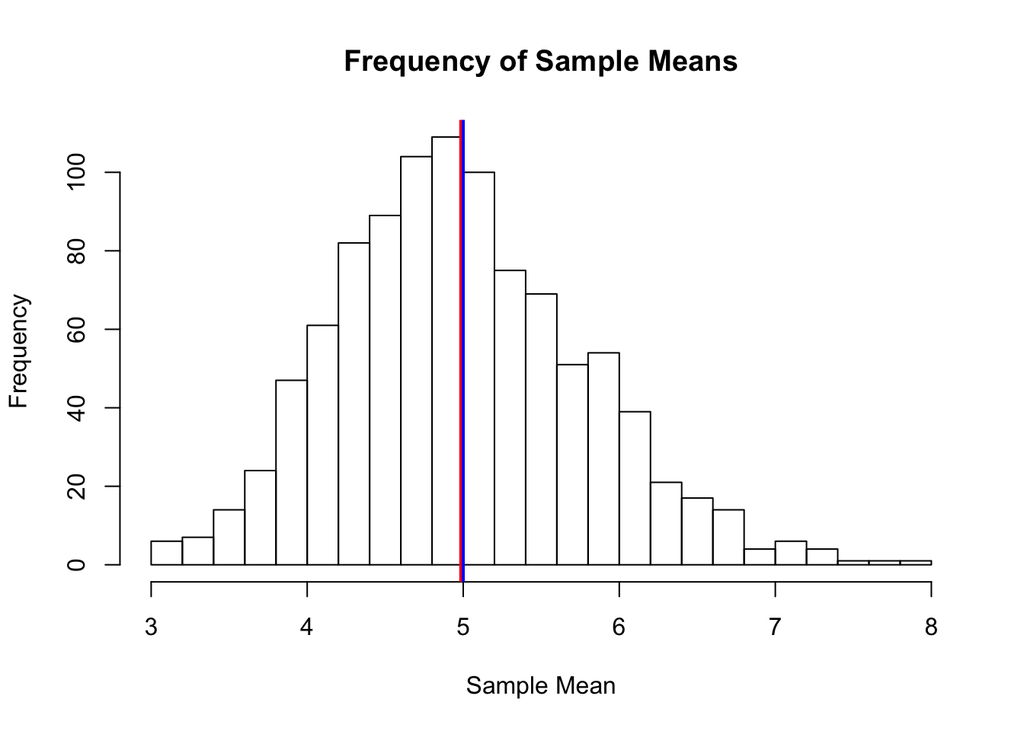

```r
# Draw a histogram with the data points that we collected
hist(
    row.mean,
    xlab = 'Sample Mean',
    main='Frequency of Sample Means',
    breaks = 20
)

# Add in a vertical line at the actual mean
abline(
    v = actual.mean,
    col = 'red',
    lwd = 2
)

# Add in a vertical line at the theoretical mean
abline(
    v = theoretical.mean,
    col = 'blue',
    lwd = 2
)
```

As you can see, both the calculated sample mean, and the theoretical means are very close to each other. Because of this we are able to say that this distribution is approximately normal.